# Partial fourier reconstruction POCS

```python
import BrukerMRI as bruker
import pylab as pl
import plot
#Python method of extracting raw Bruker Files
import BrukerMRI as bruker

# Modules
import pandas as pd
import pydicom as dcm
import math
import numpy as np
import matplotlib.pyplot as plt
import glob
from os.path import expanduser
import os
from matplotlib import cm
import cmath
```

## Functions

```python
def partial_fourier(k_sp,upper_or_lower,percentage):
    k_space = k_sp.copy()
    frac = percentage/100
    k_sp_frac = np.empty(k_sp.shape,dtype ='complex')
    start = 0
    end = 0

    if upper_or_lower == "up":
        start = 0
        end = int(frac*(int(k_space.shape[0])))

    elif upper_or_lower == "lower":
        start = k_space.shape[0]-int(frac*(int(k_space.shape[0])))
        end = k_space.shape[0]

    for i in range(start,end):
        k_sp_frac[i,:] = k_space[i,:]

    return k_sp_frac
```

```python
def img_diff(corrected,original):
    c = np.abs(corrected - np.abs(original));
    return c
```

## Phantom

```python
from phantominator import shepp_logan
# MR phantom (returns proton density, T1, and T2 maps)
M0, T1, T2 = shepp_logan((128, 128,20), MR=True)
```

```python
### Applying a Phase to a Real Image
nx = 128
[x,y,z] = np.meshgrid(range(0,nx),range(0,nx),range(0,20))
phase = np.sqrt(np.power((x-nx/4)/5,2) + np.power((y-nx/6)/10,2))
phase.shape

M1 = M0.copy()
M1_phased = M1 * np.exp(1j*phase)

### Selecting a Single Slice
M1_phased_6 = M1_phased[:,:,6]

### K-Space of Phased Image, M1_Phased
M1_ksp_single = np.fft.fftshift(np.fft.fft2((M1_phased_6)))


### 3Q Partial Fourier
M1_ksp_3Q = partial_fourier(M1_ksp_single,'up',75)

### 3Q Partial Fourier

img_3Q = np.fft.ifft2(np.fft.fftshift(M1_ksp_3Q))
```

## Algorithm 4 - Projection onto convex sets (POCS)

Now we consider a different approach to Partial Fourier reconstruction, using an iterative reconstruction method called "Projection onto Convex Sets", or POCS. To do this, let's consider what information we have to solve our under-determined image reconstruction problem:

- We know the data should be consistent with the measured 75% of k-space
- We know the image phase, or equivalently, we know the our estimate should be non-negative real and can define the solution to our image reconstruction problem as any image where both 1 and 2 are true.
- If we redefine 1 and 2 as set constraints, we can then re-state our solution as any image that lies in the intersection of these two constraint sets.
- POCS, it turns out, is a general algorithm for finding set intersections, assuming the constraint sets are convex (which they are in this case).

### Steps to Take

1. alternating between projecting the current iterate onto each constraint set in turn, until the iterate stops changing (intersection has been reached)
2. alternate between projecting onto the data-consistency set (by replacing the sampled k-space into the currrent iterate)
3. projecting onto the set of non-negative real numbers (by setting each voxel to be real and ≥ 0):

### Applying Algorithm 4

#### Generate a Low Resolution Phase Estimate

```python
N_x = M1_ksp_3Q.shape[1]
N_y = 128
x = np.linspace(0,N_x,N_x)
y = np.linspace(0,N_y,N_y)
xv, yv = np.meshgrid(x, y)
hanning = 0.5*(1-np.cos(2*np.pi*(yv)/(N_y-1)))
```

```python
up = int(nx/2-10)
low = int(nx/2+10)
centre_PFksp = M1_ksp_3Q[up:low,:]
phs = np.zeros(M1_ksp_3Q.shape, dtype = 'complex')
phs[up:low,:] = centre_PFksp*hanning[up:low,:]
phs2 = np.exp(1j*np.angle((np.fft.ifft2(np.fft.ifftshift(phs)))))
```

```python
# 1 Initialise parameters, starting image of zeros
import math
#k-sapce
ref = M1_ksp_3Q.copy()
#Two dimentional array
img_pocs = np.zeros((ref.shape))
diff = math.inf
i = 0

while (diff > 1e-15 and i < 3500):

    ## Applying Phase Correction of Iterative Image
    tmp_i = img_pocs*phs2

    ## k-space of phase corrected imgae
    tmp_k = np.fft.fftshift(np.fft.fft2(tmp_i,))

    # k-space of original 3Q K-space
    tmp_k[0:96,:] = ref[0:96,:]

    # image of Partial K-space multiplied by the conjugate of the low resolution phase estimate
    tmp_i_2 = np.fft.ifft2(np.fft.fftshift(tmp_k))*np.conj(phs2)

    # Extraction of only real and non-negative values of images
    tmp_ir = np.real(tmp_i_2)
    tmp_ir[tmp_ir < 0] = 0

    ## update
    ## the difference of the
    diff = np.linalg.norm(tmp_ir.flatten() - img_pocs.flatten())/np.linalg.norm(img_pocs)
    print(i,' ',diff)
    #image
    img_pocs = tmp_ir
    i += 1
    print(diff)
```

```
0   inf
inf
1   0.029113787013881256
0.029113787013881256
2   0.01401606956881118
0.01401606956881118
3   0.006902374217081382
0.006902374217081382
4   0.003461714749400718
0.003461714749400718
5   0.0017646260411049602
0.0017646260411049602
6   0.0009133538429987347
0.0009133538429987347
7   0.00048550514946388415
0.00048550514946388415
8   0.00026840182364783937
0.00026840182364783937
9   0.00015559571122679563
0.00015559571122679563
10   9.504686360291929e-05
9.504686360291929e-05
11   6.112982624653215e-05
6.112982624653215e-05
12   4.11504068035507e-05
4.11504068035507e-05
13   2.8753260317743853e-05
2.8753260317743853e-05
14   2.0680602592790345e-05
2.0680602592790345e-05
15   1.520587407267274e-05
1.520587407267274e-05
16   1.1371305413167153e-05
1.1371305413167153e-05
17   8.616140131279539e-06
8.616140131279539e-06
18   6.594501858328555e-06
6.594501858328555e-06
19   5.087639156678495e-06
5.087639156678495e-06
```

[output cut: 179 more lines]

```
4.364477010800345e-15
110   3.4672822564517772e-15
3.4672822564517772e-15
111   2.7543929437917696e-15
2.7543929437917696e-15
112   2.1851744110897e-15
2.1851744110897e-15
113   1.7377488972518704e-15
1.7377488972518704e-15
114   1.3814282747154085e-15
1.3814282747154085e-15
115   1.101481080279077e-15
1.101481080279077e-15
116   8.786668352534155e-16
8.786668352534155e-16
```

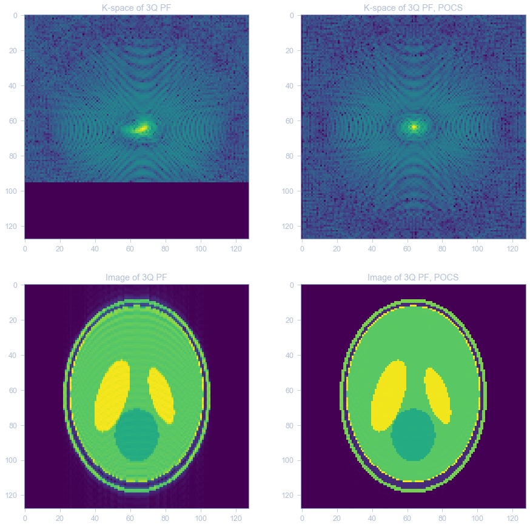

```python
plt.figure(figsize=(15,15))

plt.subplot(221)
plt.imshow(np.log(1+np.abs(M1_ksp_3Q)))
plt.title('K-space of 3Q PF')

plt.subplot(222)
plt.imshow(np.log(1+np.abs(np.fft.fftshift(np.fft.fft2((img_pocs))))))
plt.title('K-space of 3Q PF, POCS')

plt.subplot(223)
plt.imshow(np.abs(img_3Q), vmin=0, vmax=1)
plt.title('Image of 3Q PF')

plt.subplot(224)
plt.imshow(np.abs(img_pocs), vmin=0, vmax=1)
plt.title('Image of 3Q PF, POCS')
```

### Applying POCS, Pauli

```python
start  = M1_ksp_3Q.copy()
k_pocs = np.zeros((start.shape),'complex')
center_k = np.zeros((start.shape),'complex')
diff1 = 1
i = 0
while (diff1 > 1E-15 ):#i<2):
    #Two dimentional array
    #img_pocs_p is the iterative k-space
    #center_k is the symmetrically sampled from partial k-space
    k_pocs[:96,:] = start[:96,:]
    center_k[int((start.shape[0]/2)-5):int((start.shape[0]/2)+5),:] = start[int((start.shape[0]/2)-5):int((start.shape[0]/2)+5),:]
    img_ck = np.fft.ifft2(np.fft.fftshift(center_k))

    # phase of the symmetrically acquired image
    phase = np.exp(1j*np.angle(img_ck))

    #image before correction
    img_start = np.fft.ifft2(np.fft.fftshift(start))
    img_start_abs = np.abs(img_start)

    #Phase constrained image data
    phase_con_img = img_start_abs*phase

    # K-space of Phase constrained image data to produce nmissing lines of k-space
    k_phase_con_img = np.fft.fftshift(np.fft.fft2(phase_con_img))

    #Replace bottom of the phase corrected k-space to the Partial k-space

    k_pocs[96:,:] = k_phase_con_img[96:,:]
    img_pocs2 = np.fft.ifft2((np.fft.fftshift(k_pocs)))

    diff2 = diff1
    diff1 = np.linalg.norm(img_start.flatten() - img_pocs2.flatten())/np.linalg.norm(img_pocs2)

    #image
    start = k_pocs
    i += 1
    print(i,diff1)
```

```
1 0.04773109112042538
2 0.019608557767345138
3 0.009487840319376929
4 0.004657567665080557
5 0.002297576707736668
6 0.0011404807637812214
7 0.0005696776024162453
8 0.0002861187873010893
9 0.00014429332913501577
10 7.296661672848353e-05
11 3.69570509541093e-05
12 1.8738295832144042e-05
13 9.50794549967982e-06
14 4.827279711587585e-06
15 2.4519687125431133e-06
```

[output cut: 34 more lines]

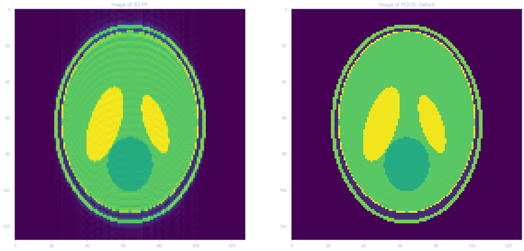

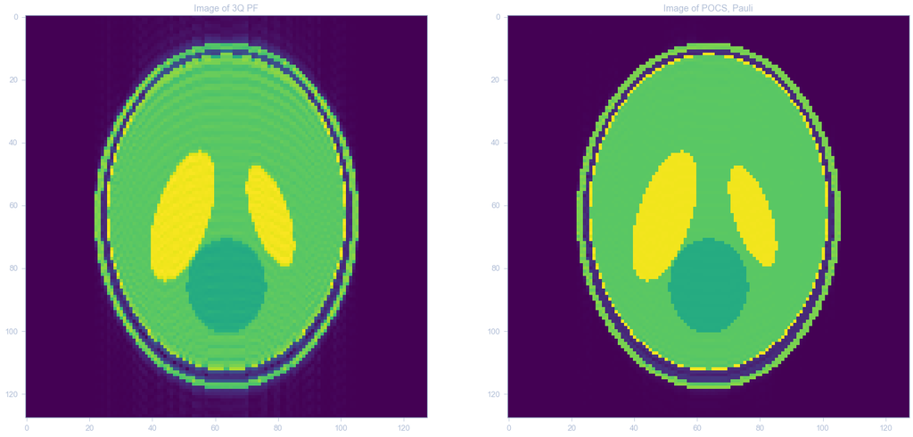

```python
plt.figure(figsize=(25,25))

plt.subplot(121)
plt.imshow(np.abs(img_3Q), vmin=0, vmax=1)
plt.title('Image of 3Q PF')

plt.subplot(122)
plt.imshow(np.abs(img_pocs), vmin=0, vmax=1)
plt.title('Image of POCS, Oxford')

plt.figure(figsize=(25,25))
plt.subplot(121)
plt.imshow(np.abs(img_3Q), vmin=0, vmax=1)
plt.title('Image of 3Q PF')

plt.subplot(122)
plt.imshow(np.abs(img_pocs2), vmin=0, vmax=1)
plt.title('Image of POCS, Pauli')
```